# R語言code整理

# 1. Introduction

## (1) Calculator

```r
5 + 3
```

```
## [1] 8
```

```r
5 * 3
```

```
## [1] 15
```

```r
5 / 3
```

```
## [1] 1.666667
```

```r
5 ^ 3
```

```
## [1] 125
```

```r
5 %% 3
```

```
## [1] 2
```

```r
5 %/% 3
```

```
## [1] 1
```

## (2) Sequence

```r
1:10
```

```
##  [1]  1  2  3  4  5  6  7  8  9 10
```

```r
seq(1, 10, 2)
```

```
## [1] 1 3 5 7 9
```

```r
seq(1, 10, length.out = 6)
```

```
## [1]  1.0  2.8  4.6  6.4  8.2 10.0
```

## (3) Basic features

We tell R to make the assignment using an arrow “<-”. R also supports using “=” in most circumstances. However, “<-” is recommended as it makes clear that we are requesting an assignment, rather than stating a relation.

```r
a <- 3 ^ 5
b = 3 ^ 5
a
```

```
## [1] 243
```

```r
b
```

```
## [1] 243
```

## (4) Special values in R

Missing value, Not a Number, Infinity, π, and 10^−3:

```r
NA
```

```
## [1] NA
```

```r
NaN
```

```
## [1] NaN
```

```r
Inf
```

```
## [1] Inf
```

```r
-Inf
```

```
## [1] -Inf
```

```r
pi
```

```
## [1] 3.141593
```

```r
1e-3
```

```
## [1] 0.001
```

## (5) R us not just an calculator

There are a lot of functions you can use. Let’s see some related to Statistics.

Descriptive statistics:

```r
x <- 1:25

mean(x)
```

```
## [1] 13
```

```r
var(x)
```

```
## [1] 54.16667
```

```r
median(x)
```

```
## [1] 13
```

```r
quantile(x, c(0.1, 0.5, 0.7))
```

```
##  10%  50%  70%
##  3.4 13.0 17.8
```

```r
x <- c(1:25, NA)
summary(x)
```

```
##    Min. 1st Qu.  Median    Mean 3rd Qu.    Max.    NA's
##       1       7      13      13      19      25       1
```

# 2. Vectors

## (1) Numeric vector

```r
vt1 <- c(1:5)
vt2 <- c(3:6)
vt2 <- c(vt2, vt1)
vt2
```

```
## [1] 3 4 5 6 1 2 3 4 5
```

Use “seq()” and “rep()” to construct a vector with similar patterns

```r
seq(1, 5, by = 0.5)
```

```
## [1] 1.0 1.5 2.0 2.5 3.0 3.5 4.0 4.5 5.0
```

```r
seq(1, 10, length.out = 5)
```

```
## [1]  1.00  3.25  5.50  7.75 10.00
```

```r
rep(3, 12)
```

```
##  [1] 3 3 3 3 3 3 3 3 3 3 3 3
```

```r
rep(seq(2, 10, 2), 2)
```

```
##  [1]  2  4  6  8 10  2  4  6  8 10
```

創建null vector，再進行迭代

```r
a <- c(3, 5, 9, 10)
b <- c(14, 15, 17)
V1 <- c()
V1 <- c(V1, a, b)
V1
```

```
## [1]  3  5  9 10 14 15 17
```

When to use “c( )” and when to use a vector with known length? c( ): Easy to add a value into the vector; need not know the length. rep(NA, n): With known length and the position of elements.

### elements in the vector

*Use “unique( )” to return the elements that appear at least one time.

*Use “table( )” to count the number of each element from the vector.

```r
b <- c(3, 3, 3, 3, 5, 5, 1, 2, 10, 10, 8)

unique(b)
```

```
## [1]  3  5  1  2 10  8
```

```r
table(b)
```

```
## b
##  1  2  3  5  8 10
##  1  1  4  2  1  2
```

Sorting and ordering of a vector

```r
a <- c(3, 4, 2, 7, 10, 23, 8, 9, 11)
sort(a)
```

```
## [1]  2  3  4  7  8  9 10 11 23
```

```r
sort(a, decreasing = TRUE)
```

```
## [1] 23 11 10  9  8  7  4  3  2
```

change values in a vector&Deleting elements from a vector

```r
a <- c(3, 4, 2, 7, 10, 23, 8, 9, 11)
a[5] <- -3
a[8] <- -1
a
```

```
## [1]  3  4  2  7 -3 23  8 -1 11
```

```r
vt1
```

```
## [1] 1 2 3 4 5
```

```r
vt1[-2]
```

```
## [1] 1 3 4 5
```

```r
## [1] 1 3 4 5
```

## (2) Character vectors

```r
"Hello World!!!"
```

```
## [1] "Hello World!!!"
```

```r
print("Hello R World!!!")
```

```
## [1] "Hello R World!!!"
```

*Character vector: the vector is made up of strings of characters.

*All elements of a vector must be of the same type.

```r
colors <- c("red", "yellow", "BLUE")
more.colors <- c(colors, "green", "cyan")
more.colors
```

```
## [1] "red"    "yellow" "BLUE"   "green"  "cyan"
```

```r
##An attempt to mix data types in a vector
z <- c("red", "green", 12)
z
```

```
## [1] "red"   "green" "12"
```

Basic operations for character vectors

```r
y.in.V <- grep("y", more.colors)
e.in.V <- grep("e", more.colors)
more.colors[y.in.V]
```

```
## [1] "yellow" "cyan"
```

```r
more.colors[e.in.V]
```

```
## [1] "red"    "yellow" "green"
```

```r
E.in.V <- grep("E", more.colors)
more.colors[E.in.V]
```

```
## [1] "BLUE"
```

-To building up strings, use “paste()”.

```r
paste(colors, "line") ## with space
```

```
## [1] "red line"    "yellow line" "BLUE line"
```

```r
paste(colors, "line", sep = "" ) ## no space
```

```
## [1] "redline"    "yellowline" "BLUEline"
```

```r
## use ";" to seperate strings
paste("I like", colors, collapse = "; ")
```

```
## [1] "I like red; I like yellow; I like BLUE"
```

## (3) Logical vectors

TRUE and FALSE are reserved words denoting logical constants in the R,

whereas T and F are global variables whose initial values set to these.

```r
TRUE
```

```
## [1] TRUE
```

```r
FALSE
```

```
## [1] FALSE
```

```r
T
```

```
## [1] TRUE
```

```r
F
```

```
## [1] FALSE
```

Binary operators which allow the comparison of values in atomic vectors (relational operators).

Number: Compare 3 and 5

“==”: equal

“!=”: not equal

```r
c(3 < 5, 3 > 5)
```

```
## [1]  TRUE FALSE
```

```r
c(3 <= 5, 3 >= 5)
```

```
## [1]  TRUE FALSE
```

```r
3 == 5
```

```
## [1] FALSE
```

```r
3 != 5
```

```
## [1] TRUE
```

Compare the same location of elements individually.

```r
B <- c(3, 1, 5, 4, 7); C <- c(23, 1, 44, 5, 3)
B == C
```

```
## [1] FALSE  TRUE FALSE FALSE FALSE
```

```r
D <- c(2, 5 ,6, 10)
B == D
```

```
## [1] FALSE FALSE FALSE FALSE FALSE
```

### “is.” series

“is.XYZ()” is any comparison to the type “XYZ” of an object.

is.null()

is.na()

is.nan()

is.infinite()

is.character()

is.integer()

is.numeric()

```r
is.null(c())
```

```
## [1] TRUE
```

```r
c(is.na(NA), is.na(2))
```

```
## [1]  TRUE FALSE
```

```r
x1 <- 1:5
x2 <- c(1:3, 2.2)
x3 <- colors
c(is.integer(x1), is.numeric(x1), is.double(x1))
```

```
## [1]  TRUE  TRUE FALSE
```

```r
c(is.integer(x2), is.numeric(x2), is.double(x2))
```

```
## [1] FALSE  TRUE  TRUE
```

```r
c(is.character(x3), is.numeric(x3))
```

```
## [1]  TRUE FALSE
```

Use “class( )” to identify the type of a vector.

```r
a <- c(3, 4, 2, 7)
b <- c("red", "yellow", "blue")
c <- c(TRUE, FALSE)
c(class(a), class(b), class(c))
```

```
## [1] "numeric"   "character" "logical"
```

```r
c(class(2), class(2.0), class(as.integer(2)))
```

```
## [1] "numeric" "numeric" "integer"
```

# 3. Matrix

## (1) Constrct a matrix by row & column

```r
#by row
a <- 1:5; b <- 6:10;
c <- 11:15; d <- 16:20;
M1 <- rbind(a, b, c, d)
M1
```

```
##   [,1] [,2] [,3] [,4] [,5]
## a    1    2    3    4    5
## b    6    7    8    9   10
## c   11   12   13   14   15
## d   16   17   18   19   20
```

```r
#by column
M2 <- cbind(a, b, c, d)
M2
```

```
##      a  b  c  d
## [1,] 1  6 11 16
## [2,] 2  7 12 17
## [3,] 3  8 13 18
## [4,] 4  9 14 19
## [5,] 5 10 15 20
```

```r
dim(M1)
```

```
## [1] 4 5
```

```r
dim(M2)
```

```
## [1] 5 4
```

## (2) Constrct a matrix by longer vector

```r
X <- 1:20
matrix(X, nrow = 4, ncol = 5)
```

```
##      [,1] [,2] [,3] [,4] [,5]
## [1,]    1    5    9   13   17
## [2,]    2    6   10   14   18
## [3,]    3    7   11   15   19
## [4,]    4    8   12   16   20
```

```r
matrix(X, nrow = 4, ncol = 5, byrow = TRUE)
```

```
##      [,1] [,2] [,3] [,4] [,5]
## [1,]    1    2    3    4    5
## [2,]    6    7    8    9   10
## [3,]   11   12   13   14   15
## [4,]   16   17   18   19   20
```

### Features for a matrix

```r
M1
```

```
##   [,1] [,2] [,3] [,4] [,5]
## a    1    2    3    4    5
## b    6    7    8    9   10
## c   11   12   13   14   15
## d   16   17   18   19   20
```

```r
dim(M1)
```

```
## [1] 4 5
```

```r
colnames(M1); rownames(M1);
```

[output not shown]

```r
colnames(M1) <- c("V1", "V2", "V3", "V4", "V5")

dimnames(M1)
```

```
## [[1]]
## [1] "a" "b" "c" "d"
##
## [[2]]
## [1] "V1" "V2" "V3" "V4" "V5"
```

```r
dimnames(M2)
```

```
## [[1]]
## NULL
##
## [[2]]
## [1] "a" "b" "c" "d"
```

### Extract elements from a matrix

```r
M1
```

```
##   V1 V2 V3 V4 V5
## a  1  2  3  4  5
## b  6  7  8  9 10
## c 11 12 13 14 15
## d 16 17 18 19 20
```

```r
M1[5]
```

```
## [1] 2
```

```r
M1[13]
```

```
## [1] 4
```

Recall M1. The names of rows are a, b, c, and d. Take the rows of b and c

The names of columns are V1, V2, V3, V4, and V5. Take the rows of b and c and the columns of V2 and V5.

```r
M1[c("b", "c"), ]
```

```
##   V1 V2 V3 V4 V5
## b  6  7  8  9 10
## c 11 12 13 14 15
```

```r
M1[c("b", "c"), c("V2", "V5")]
```

```
##   V2 V5
## b  7 10
## c 12 15
```

### simple calculation of matrix

Note: Use **%*%** to evaluate multiplication of matrices

```r
A <- matrix(c(1:4), 2, 2)
A + 3
```

```
##      [,1] [,2]
## [1,]    4    6
## [2,]    5    7
```

```r
A - 1
```

```
##      [,1] [,2]
## [1,]    0    2
## [2,]    1    3
```

```r
A * 5
```

```
##      [,1] [,2]
## [1,]    5   15
## [2,]   10   20
```

```r
A / 4
```

```
##      [,1] [,2]
## [1,] 0.25 0.75
## [2,] 0.50 1.00
```

```r
B <- matrix(c(5:8), 2, 2)
A + B
```

```
##      [,1] [,2]
## [1,]    6   10
## [2,]    8   12
```

```r
A * B
```

```
##      [,1] [,2]
## [1,]    5   21
## [2,]   12   32
```

```r
#summary statistics
C <- matrix(1:9, 3, 3)
colSums(C)
```

```
## [1]  6 15 24
```

```r
rowSums(C)
```

```
## [1] 12 15 18
```

```r
colMeans(C)
```

```
## [1] 2 5 8
```

```r
rowMeans(C)
```

```
## [1] 4 5 6
```

```r
A %*% B
```

```
##      [,1] [,2]
## [1,]   23   31
## [2,]   34   46
```

Tranpose,Diagonal & Determinat

```r
t(A)
```

```
##      [,1] [,2]
## [1,]    1    2
## [2,]    3    4
```

```r
t(C)
```

```
##      [,1] [,2] [,3]
## [1,]    1    2    3
## [2,]    4    5    6
## [3,]    7    8    9
```

```r
diag(A)
```

```
## [1] 1 4
```

```r
diag(B)
```

```
## [1] 5 8
```

```r
det(A)
```

```
## [1] -2
```

```r
det(B)
```

```
## [1] -2
```

# 4. Control Flow

## (1) The for loop

When to use? See patterns of behaviour, not just a single instance. The for() statement allows one to specify that a certain operation should be repeated a fixed number of times. ### Example: Construct a vector as Xn+1 = 2Xn + 3, where X0 = 3, n = 1, 2, 3, 4, 5, 6, 7.

```r
vec.X.v1 <- c()
Xn <- 3
for(n in 1:7){
Xn <- 2*Xn + 3
vec.X.v1 <- c(vec.X.v1, Xn)
}
vec.X.v1
```

```
## [1]   9  21  45  93 189 381 765
```

Evaluate n!

n! = n ∗ (n − 1) ∗ (n − 2) ∗ · · · ∗ 2 ∗ 1. Try n = 10.

```r
n <- 10
ans <- 1
for(j in n:1){
ans <- ans * j
}
ans
```

```
## [1] 3628800
```

```r
factorial(n)
```

```
## [1] 3628800
```

For loop in matrix

evaluate the mean for each row.

```r
A <- matrix(c(3, 2, 1, 2, 2, 6, 4, 1,
4, 8, 6, 2, 5, 10, 8, 6,
3, 4, 3, 4), 4, 5)
nr <- dim(A)[1]
m <- c()
for(j in 1:nr){
m <- c(m, mean(A[j, ]))
}
m
```

```
## [1] 3.4 6.0 4.4 3.0
```

## (2) The if statement

Try to find the locations of NA

```r
C <- c(3, 4, NA, 12, 0.2, NA, -2)
for(i in 1:7){
if(is.na(C[i])) print(i)
}
```

```
## [1] 3
## [1] 6
```

Count the number of each class

```r
basket <- c("r", "b", "y", "y", "y", "r", "r", "b")
n.r <- 0; n.b <- 0; n.y <- 0
for(i in 1:length(basket)){
if(basket[i] == "r"){
n.r <- n.r + 1
}else if(basket[i] == "b"){
n.b <- n.b + 1
}else{
n.y <- n.y + 1
}
}
c(n.r, n.b, n.y)
```

```
## [1] 3 2 3
```

Re-assign the value to the class

Let “r” be 1, “b” be 2, and “y” be 3

```r
v.basket <- rep(NA, length(basket))
for(i in 1:length(basket)){
if(basket[i] == "r"){
v.basket[i] <- 1
}else if(basket[i] == "b"){
v.basket[i] <- 2
}else{
v.basket[i] <- 3
}
}
v.basket
```

```
## [1] 1 2 3 3 3 1 1 2
```

ifelse(condition, commands when TRUE, commands when FALSE) Let “r” be 1, “b” be 2, and “y” be 3

```r
v.basket <- ifelse(basket == "r", 1, ifelse(basket == "b", 2, 3))
v.basket
```

```
## [1] 1 2 3 3 3 1 1 2
```

## (3) The while loop

The pattern of repetition isn’t known in advance and we need to do some calculations and keep going as long as a condition holds. The while()statement accomplishes this.

### Relationship between for() and while()

*while(): Need the initial, condition of stopping, and iteration or replacement

```r
for(j in 1:8){
print(j)
}
```

```
## [1] 1
## [1] 2
## [1] 3
## [1] 4
## [1] 5
## [1] 6
## [1] 7
## [1] 8
```

```r
j <- 1
while(j <= 8){
print(j)
j <- j + 1
}
```

```
## [1] 1
## [1] 2
## [1] 3
## [1] 4
## [1] 5
## [1] 6
## [1] 7
## [1] 8
```

Flip a coin

```r
coin <- c(0, 0, 0, 0, 0, 0, 1, 0, 1, 0, 1, 0,
1, 1, 0, 1, 1, 0, 0, 0, 1, 0, 1, 0,
0, 0, 0, 0, 0, 0, 1)
N <- c(); j <- 1
while(j <= length(coin)){
n.fail <- 0
while(coin[j] != 1){
n.fail <- n.fail + 1
j <- j + 1
}
N <- c(N, n.fail + 1)
j <- j + 1
}
N
```

```
##  [1] 7 2 2 2 1 2 1 4 2 8
```

### break,repeat and next

*break

if (condition) break

The break statement causes the loop to terminate immediately. break statements

can also be used in for() and while() loops.

*repeat

Use “repeat” to repeat until we execute a break statement.

repeat { statements }

This causes the statements to be repeated endlessly.

*next:

The next statement causes control to return immediately to the top of the loop; it

can also be used in any loop.

***我們利用Fibonacci numbers to demo

List all Fibonacci numbers less than 100. Use for() and if(condition) break.

```r
Fib1 <- 1
Fib2 <- 1
Fibonacci <- c(Fib1)
for(j in 1:1000){
if(Fib2 < 100){
Fibonacci <- c(Fibonacci, Fib2)
Fib1 <- Fibonacci[length(Fibonacci) - 1]
Fib2 <- Fib1 + Fibonacci[length(Fibonacci)]
}else{
break
}
}
Fibonacci
```

```
##  [1]  1  1  2  3  5  8 13 21 34 55 89
```

List all Fibonacci numbers less than 100. Use repeat{ } and break.

```r
Fib1 <- 1
Fib2 <- 1
Fibonacci <- c(Fib1)
repeat
{
if(Fib2 < 100){
Fibonacci <- c(Fibonacci, Fib2)
Fib1 <- Fibonacci[length(Fibonacci) - 1]
Fib2 <- Fib1 + Fibonacci[length(Fibonacci)]
}else{
break
}
}
Fibonacci
```

```
##  [1]  1  1  2  3  5  8 13 21 34 55 89
```

```r
Fib1 <- 1
Fib2 <- 1
Fibonacci <- c(Fib1)
for(j in 1:100){
if(Fib2 >= 100) next
Fibonacci <- c(Fibonacci, Fib2)
Fib1 <- Fibonacci[length(Fibonacci) - 1]
Fib2 <- Fib1 + Fibonacci[length(Fibonacci)]
#print(j)
}
Fibonacci
```

```
##  [1]  1  1  2  3  5  8 13 21 34 55 89
```

# 5. Functions

## (1)print( ) & cat( )

```r
x <- c("A", "B", "C", "D")
print(x)
```

```
## [1] "A" "B" "C" "D"
```

```r
cat(x)
```

```
## A B C D
```

```r
cat(x[1], "\n",
x[2], "\n", sep = "" )
```

```
## A
## B
```

## (2)function( )

Use function( ) when you only have one main code for evaluation and multiple possible input, like

f (x) = 3x + 2, x = 2, 3, 4.

f means a name of a function of input x when x = 2, 3, 4

```r
f <- function(x){
3*x + 2
}
f(2); f(3); f(4)
```

```
## [1] 8
```

```
## [1] 11
```

```
## [1] 14
```

examples:

```r
make.percent <- function(x){
x.percent <- round(100*x, digits = 1)
x.show <- paste(x.percent, "%", sep = "")
cat(x.show)
}
make.percent(c(0.8933, 0.2344, 0.0764, 0.7736))
```

```
## 89.3% 23.4% 7.6% 77.4%
```

You must tell what will be return when you use the function by return( ) or invisible( ). If you don’t put return( ) at the end of the function, it will treat the last line as the result automatically

```r
f <- function(x){
return(3*x + 2)
}
f(2)
```

```
## [1] 8
```

```r
f <- function(x){
res <- 3*x + 2
}
f(2)
a <- f(2); a
```

```
## [1] 8
```

### Functions for multiple input variables

Use function( ) when you only have one main code for evaluation and

multiple possible input, like

f (x, y) = x<sup>2</sup> +y<sup>2</sup>

x, y = 2, 3, 4.

f means a name of a function of input x and y when x, y = 2, 3, 4.

```r
f <- function(x, y){
x^2 + y^2
}
f(2, 2); f(2, 3); f(2, 4)
```

```
## [1] 8
```

```
## [1] 13
```

```
## [1] 20
```

examples

```r
make.percent <- function(x, x.digits){
x.percent <- round(100*x, digits = x.digits)
x.show <- paste(x.percent, "%", sep = "")
return(x.show)
}
make.percent(c(0.8933, 0.2344, 0.0764, 0.7736), 0)
```

```
## [1] "89%" "23%" "8%"  "77%"
```

```r
make.percent(c(0.8933, 0.2344, 0.0764, 0.7736), 1)
```

```
## [1] "89.3%" "23.4%" "7.6%"  "77.4%"
```

```r
make.percent(c(0.8933, 0.2344, 0.0764, 0.7736), 2)
```

```
## [1] "89.33%" "23.44%" "7.64%"  "77.36%"
```

### Use function and return multiple outputs

list( ) is a collection of multiple types of objects, like vectors, characters, numbers,

Example:

```r
X <- list(a = 3, b = c(1,2,3,4,5), c = c("A", "B"))
X
```

```
## $a
## [1] 3
##
## $b
## [1] 1 2 3 4 5
##
## $c
## [1] "A" "B"
```

Use $ or [ [ ] ]

$: the name of the element. [ [ ] ]: the location or the name of the element.

```r
X <- list(a = 3, b = c(1,2,3,4,5), c = c("A", "B"))
X$a
```

```
## [1] 3
```

```r
X[[2]]
```

```
## [1] 1 2 3 4 5
```

```r
X[["c"]]
```

```
## [1] "A" "B"
```

Use function( ) and list( )

```r
perfect.number <- function(a, b){
k <- a
res <- c()
ans <- list()
while(k < b){
fac <- c()
for(j in 1:k){
if((k %% j) == 0) fac <- c(fac, j)
}
if(k == sum(fac[-length(fac)])) {
res <- c(res, k)
ans[[paste(k)]] <- fac[-length(fac)]
}
k <- k+1
}
ans$number <- res
return(ans)
}
```

Output: perfect number

```r
Ans <- perfect.number(1, 100)
Ans
```

```
## $`6`
## [1] 1 2 3
##
## $`28`
## [1]  1  2  4  7 14
##
## $number
## [1]  6 28
```

# 6. Related to data

## (1)data.frame( )

*Most data sets are stored in R as data frames.

*These are like matrices, but with the columns having their own names.

*Columns can be of different types from each other.

Use the data.frame() to construct data frames from vectors:

example:

```r
colors <- c("red", "yellow", "blue")
numbers <- c(1, 2, 3)
colors.and.numbers <- data.frame(colors, numbers,
more.numbers = c(4, 5, 6))
colors.and.numbers
```

```
##   colors numbers more.numbers
## 1    red       1            4
## 2 yellow       2            5
## 3   blue       3            6
```

### Difference from a matrices

These are like matrices, but with the columns having their own names.

Columns can be of different types from each othe

```r
X <- matrix(NA, 3, 3)
X[,1] <- c("red", "yellow", "blue")
X[,2] <- c(1, 2, 3)
X[,3] <- c(4, 5, 6)
colnames(X) <- c("colors", "numbers", "more.numbers")
X
```

```
##      colors   numbers more.numbers
## [1,] "red"    "1"     "4"
## [2,] "yellow" "2"     "5"
## [3,] "blue"   "3"     "6"
```

Use str() to examine the types of columns in the data frame.

```r
str(colors.and.numbers)
```

```
## 'data.frame':    3 obs. of  3 variables:
##  $ colors      : chr  "red" "yellow" "blue"
##  $ numbers     : num  1 2 3
##  $ more.numbers: num  4 5 6
```

```r
colors <- c("red", "yellow", "blue")
numbers <- c(1, 2, 3)
colors.and.numbers <- data.frame(colors, numbers,
more.numbers = c(4, 5, 6),
stringsAsFactors = FALSE)
str(colors.and.numbers)
```

```
## 'data.frame':    3 obs. of  3 variables:
##  $ colors      : chr  "red" "yellow" "blue"
##  $ numbers     : num  1 2 3
##  $ more.numbers: num  4 5 6
```

More on data.frame(): add rows

```r
data1 <- data.frame(colors, numbers, more.numbers = c(4, 5, 6),stringsAsFactors = FALSE)
data1 <- rbind(data1, c("black", 3, 5))
data1
```

```
##   colors numbers more.numbers
## 1    red       1            4
## 2 yellow       2            5
## 3   blue       3            6
## 4  black       3            5
```

More on data.frame(): add columns

```r
colors <- c("red", "yellow", "blue")
number1 <- c(1, 2, 3)
number2 <- c(10, 11, 12)
colors.and.numbers <- data.frame(colors, number1) ## construct data.frame
colors.and.numbers$more.numbers <- c(4, 5, 6) ## add one column
colors.and.numbers <- cbind(colors.and.numbers, number2) ## add one column
colors.and.numbers
```

```
##   colors number1 more.numbers number2
## 1    red       1            4      10
## 2 yellow       2            5      11
## 3   blue       3            6      12
```

# 7. Graphics

## Statistical Figure

Given an arbitray vector x:

1 Histogram: hist(x)

2 Boxplot: boxplot(x)

3 Density plot: plot(density(x))

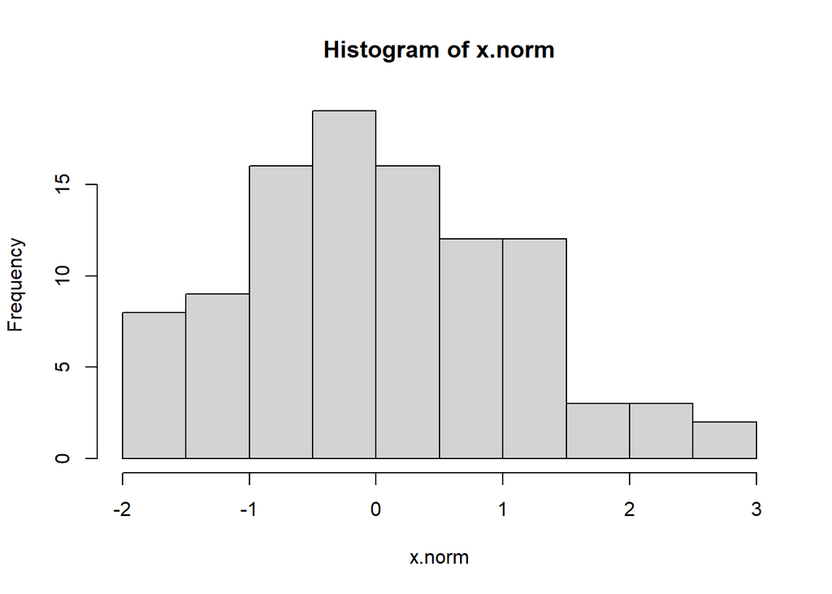

```r
x.norm <- rnorm(100, mean=0, sd=1)
hist(x.norm)
```

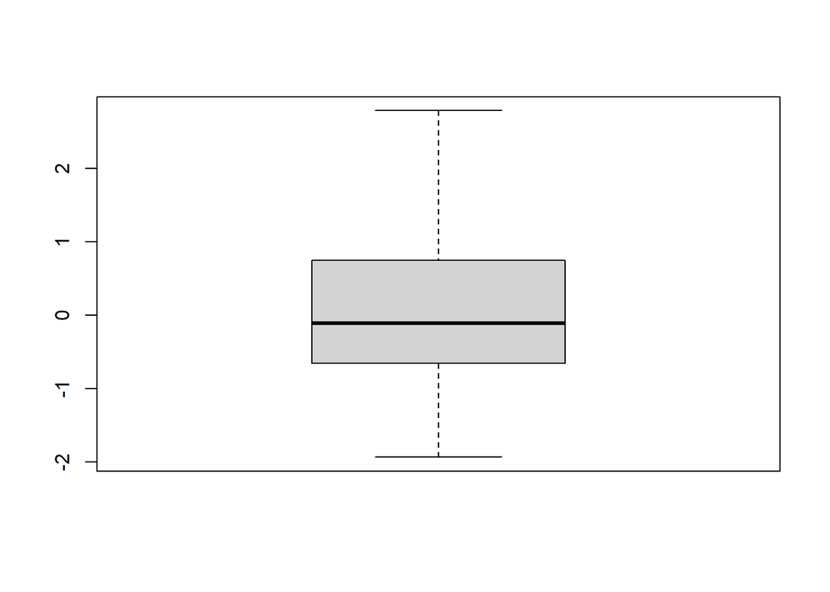

```r
boxplot(x.norm)
```

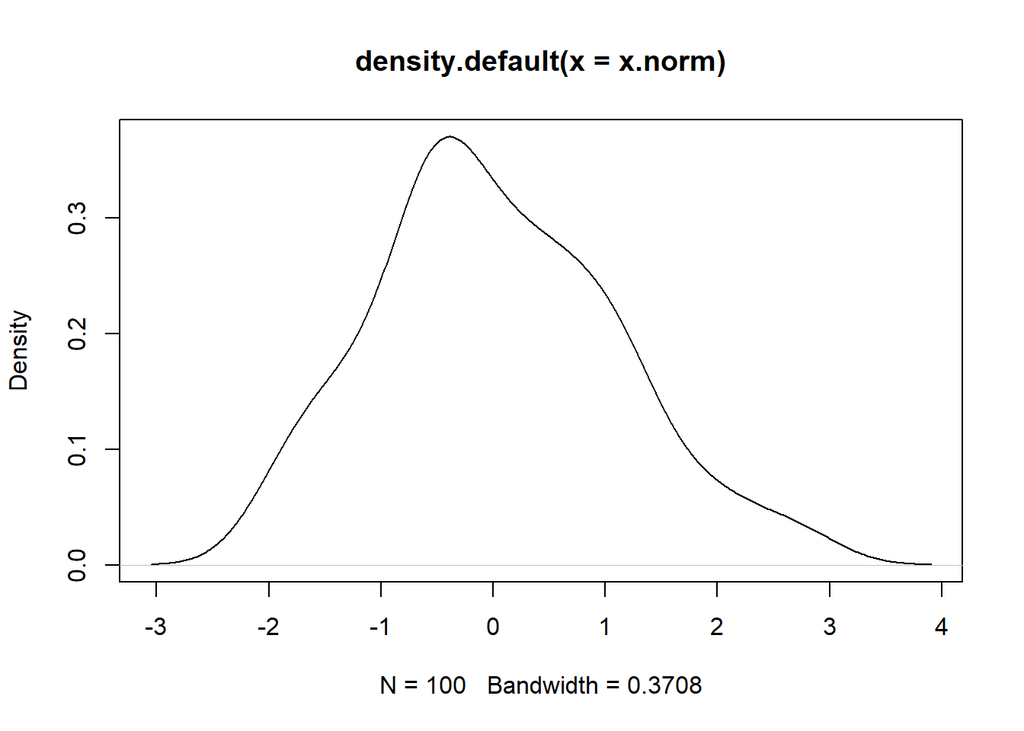

```r
plot(density(x.norm))
```

For discrete variables x:

1 Barchart: barplot(x)

2 Piechart: pie(x)

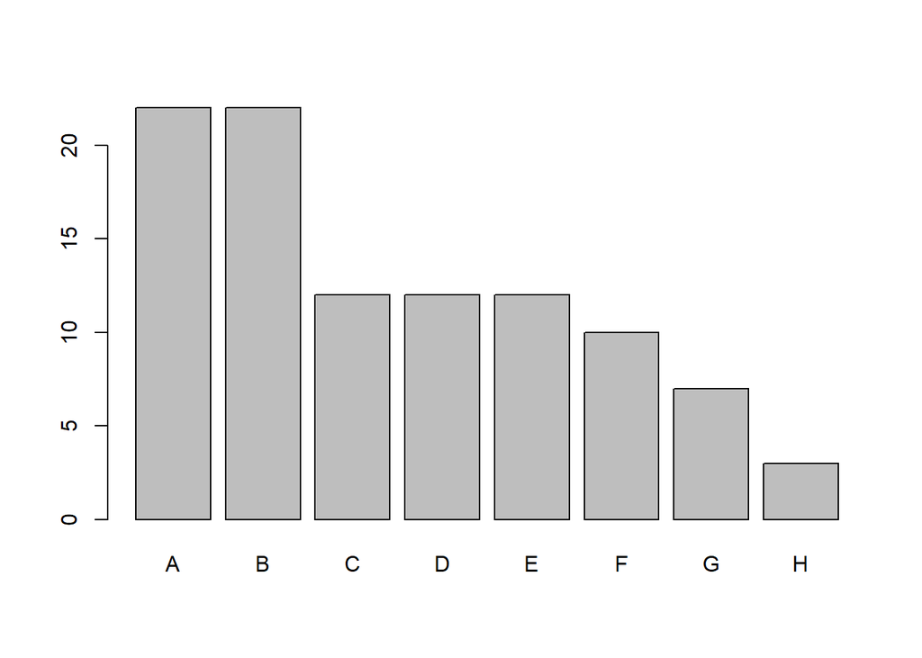

```r
x <- sample(c(1:8), 100, replace=TRUE, prob=c(8:1))
x <- table(x)
names(x) <- c("A", "B", "C", "D", "E", "F", "G", "H")
barplot(x)
```

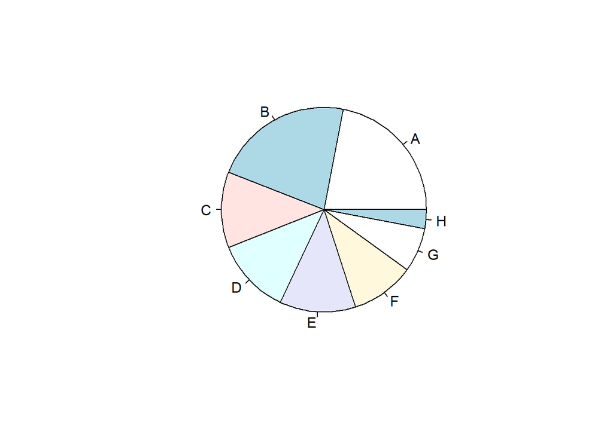

```r
pie(x)
```

Scatter plot is for the correlation between two variables. Use plot(x, y)

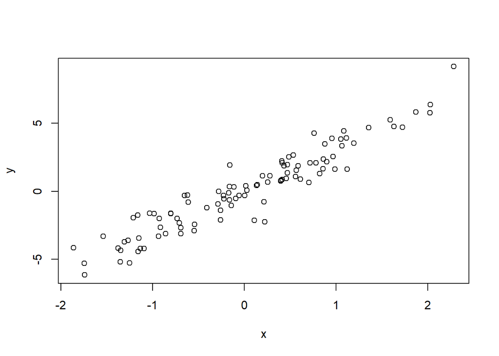

```r
x <- rnorm(100)
y <- 3*x + rnorm(100, 0, 1)
plot(x, y)
```

```r
cor(x, y)
```

```
## [1] 0.9468156
```

### General plot function: plot(. . . )

plot(x, y, type = “p”, ### types of the plot pch = , ### the symbol in the plot main = NULL, ### the title of the plot lty = , ### the style of a line lwd = , ### the width of a line cex = , ### the size of an text bty=“o”, ### the box around the plot col = , ### the color of an object xlim = NULL, ylim = NULL, # the range of an axis sub = NULL, ### the sub-title of the plot xlab = NULL, ylab = NULL, # the name of an axis cex.main = ### the size of the title )

## ggplot2 額外介紹

```r
library(ggplot2)
library(dplyr)
library(gapminder)
#散佈圖
#範例1
data("mpg")
mpg %>% head
```

```
## # A tibble: 6 x 11
##   manufacturer model displ  year   cyl trans      drv     cty   hwy fl    class
##   <chr>        <chr> <dbl> <int> <int> <chr>      <chr> <int> <int> <chr> <chr>
## 1 audi         a4      1.8  1999     4 auto(l5)   f        18    29 p     compa~
## 2 audi         a4      1.8  1999     4 manual(m5) f        21    29 p     compa~
## 3 audi         a4      2    2008     4 manual(m6) f        20    31 p     compa~
## 4 audi         a4      2    2008     4 auto(av)   f        21    30 p     compa~
## 5 audi         a4      2.8  1999     6 auto(l5)   f        16    26 p     compa~
## 6 audi         a4      2.8  1999     6 manual(m5) f        18    26 p     compa~
```

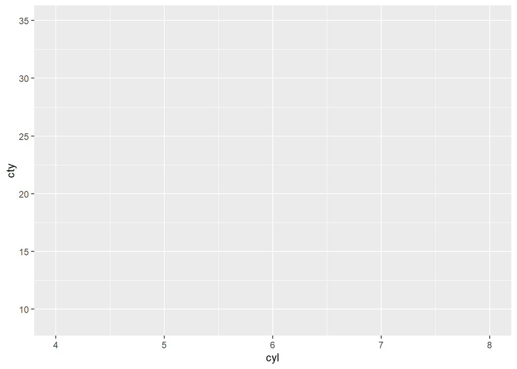

```r
canvas<-ggplot(mpg,mapping=aes(x=cyl,y=cty))
canvas #加畫布
```

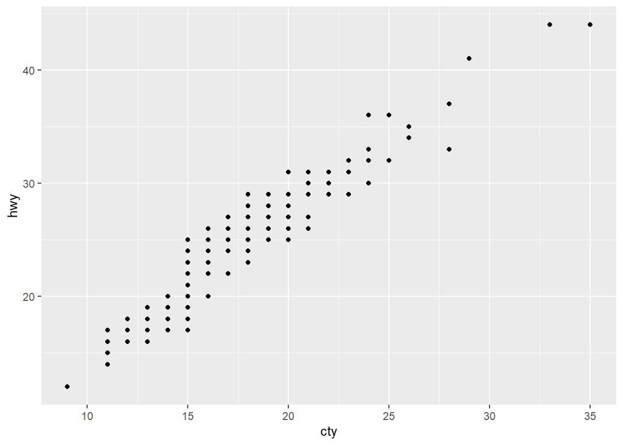

```r
e <- ggplot(mpg, aes(cty, hwy))
e + geom_point()
```

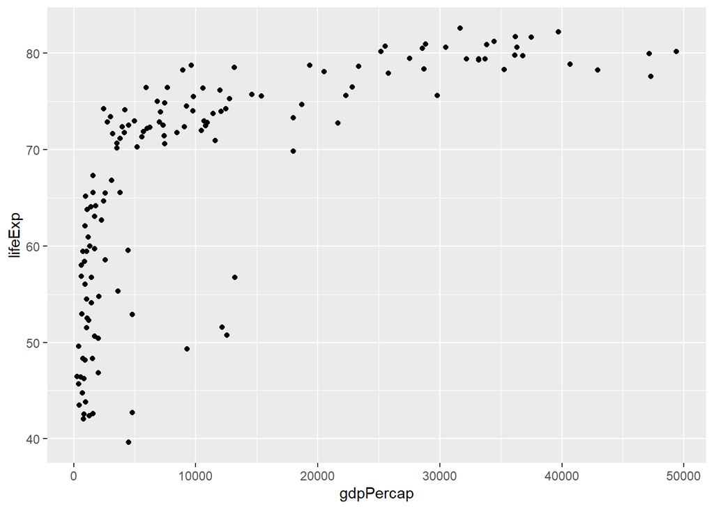

```r
#範例2
gapminder_2007 <- gapminder %>%filter(year == 2007)
scatter_plot <- ggplot(gapminder_2007, aes(x = gdpPercap, y = lifeExp)) +
  geom_point()
scatter_plot
```

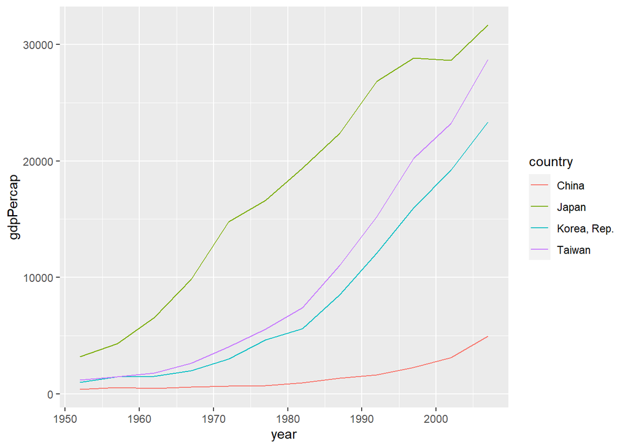

```r
#線圖
north_asia <- gapminder %>%filter(country %in% c("China", "Japan", "Taiwan", "Korea, Rep."))
line_plot <- ggplot(north_asia, aes(x = year, y = gdpPercap, colour = country)) +geom_line()
line_plot
```

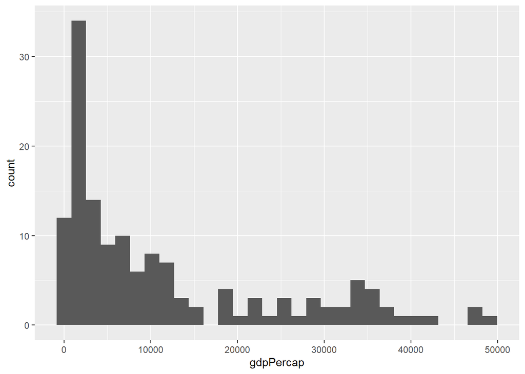

```r
#直方圖
hist_plot <- ggplot(gapminder_2007, aes(x = gdpPercap)) +geom_histogram()
hist_plot
```

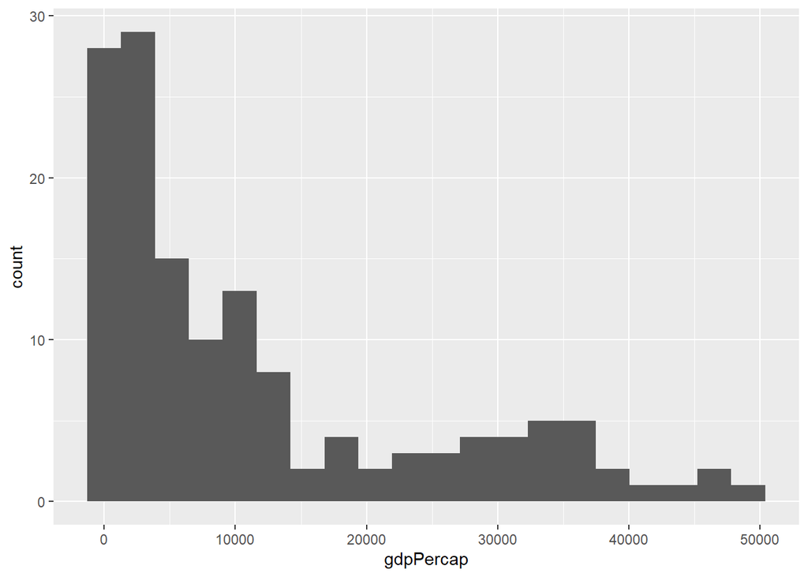

```r
#調整bin
hist_plot2 <- ggplot(gapminder_2007, aes(x = gdpPercap)) +geom_histogram(bins = 20)
hist_plot2
```

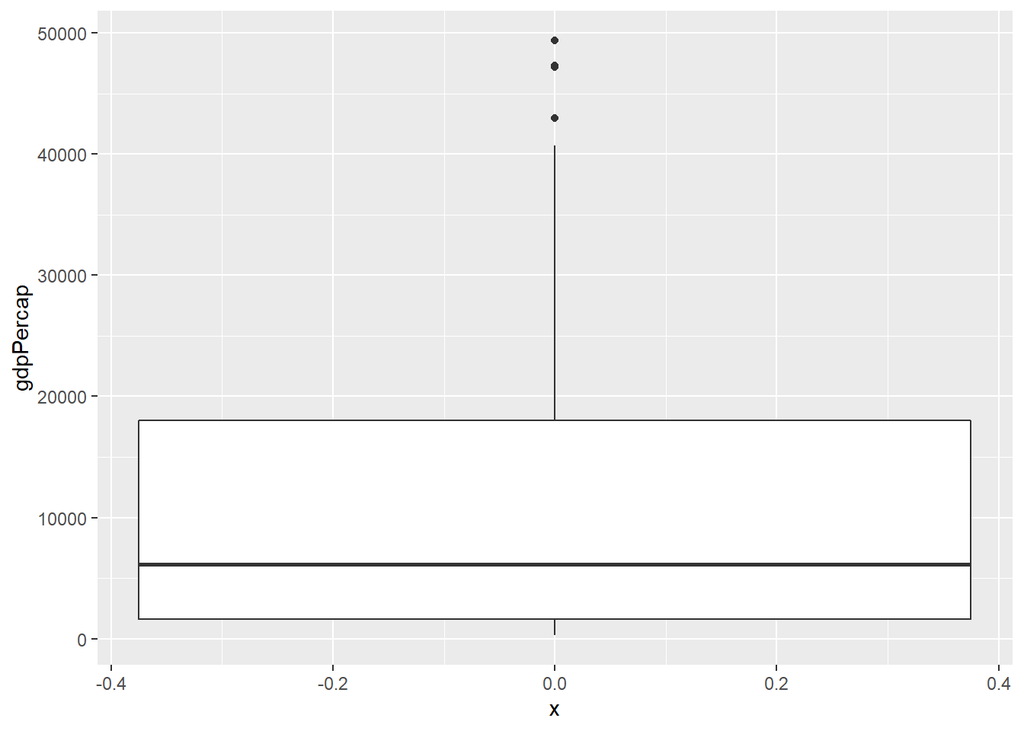

```r
#盒鬚圖
#單看一個數據
box_plot <- ggplot(gapminder_2007, aes(x = 0,y=gdpPercap)) +geom_boxplot()
box_plot
```

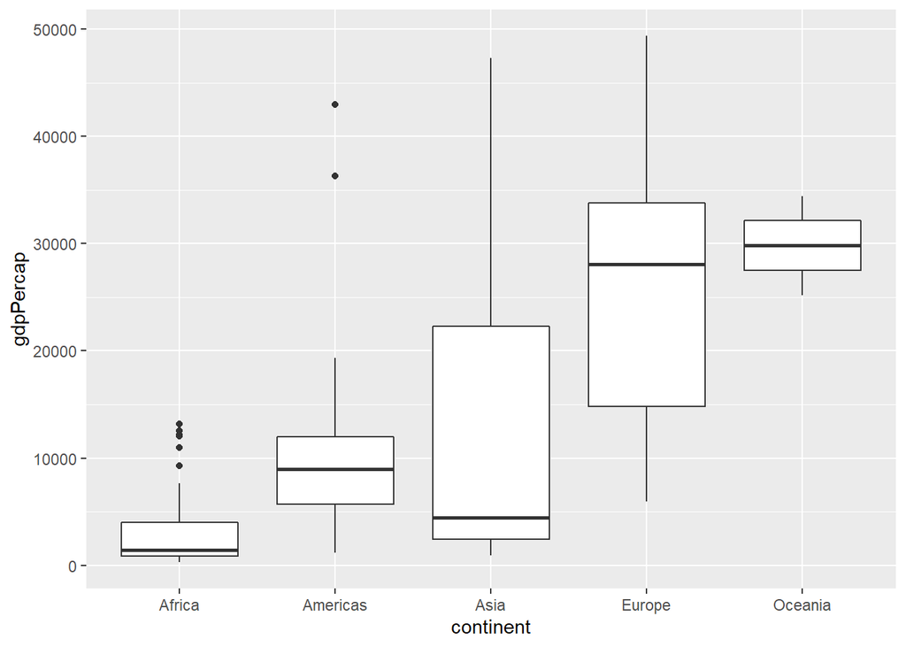

```r
#交叉比對
box_plot <- ggplot(gapminder_2007, aes(x = continent, y = gdpPercap)) +
  geom_boxplot()
box_plot
```

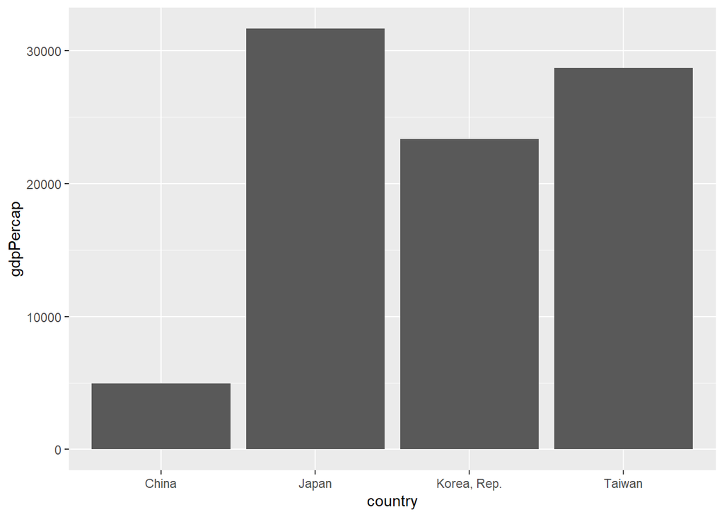

```r
#長條圖
gdpPercap_2007_na <- gapminder %>%filter(year == 2007 & country%in%c("China", "Japan", "Taiwan", "Korea, Rep."))
bar_plot <- ggplot(gdpPercap_2007_na, aes(x = country, y = gdpPercap)) +
  geom_bar(stat = "identity")
bar_plot
```

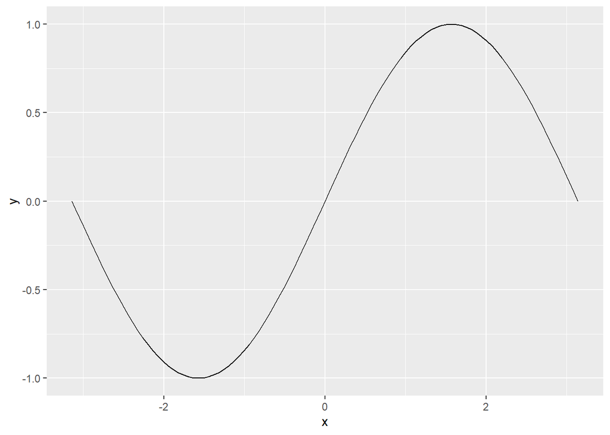

```r
#建立樣本
ice_cream_flavor<-rep(NA,100)
for(i in 1:100){
  ice_cream_flavor[i]<-sample(c("vanilla","chocolate","matcha","other"),size=1)
}
ice_cream_df<-data.frame(ice_cream_flavor=ice_cream_flavor)

flavor<-names(table(ice_cream_flavor))
votes<-as.vector(unname(table(ice_cream_flavor)))
#建造函數
#1 sin函數
sin_df<-data.frame(x=c(pi,-pi))

ggplot(sin_df,aes(x=x))+stat_function(fun=sin,geom="line")
```

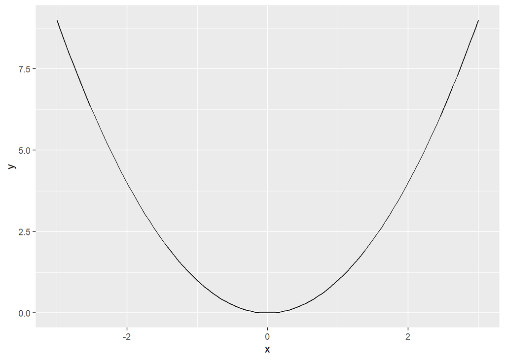

```r
#2 自創函數
X_square<-function(x){
  return(x^2)
}
range<-data.frame(x=c(-3,3))
ggplot(range,aes(x=x))+stat_function(fun=X_square,geom="line")
```

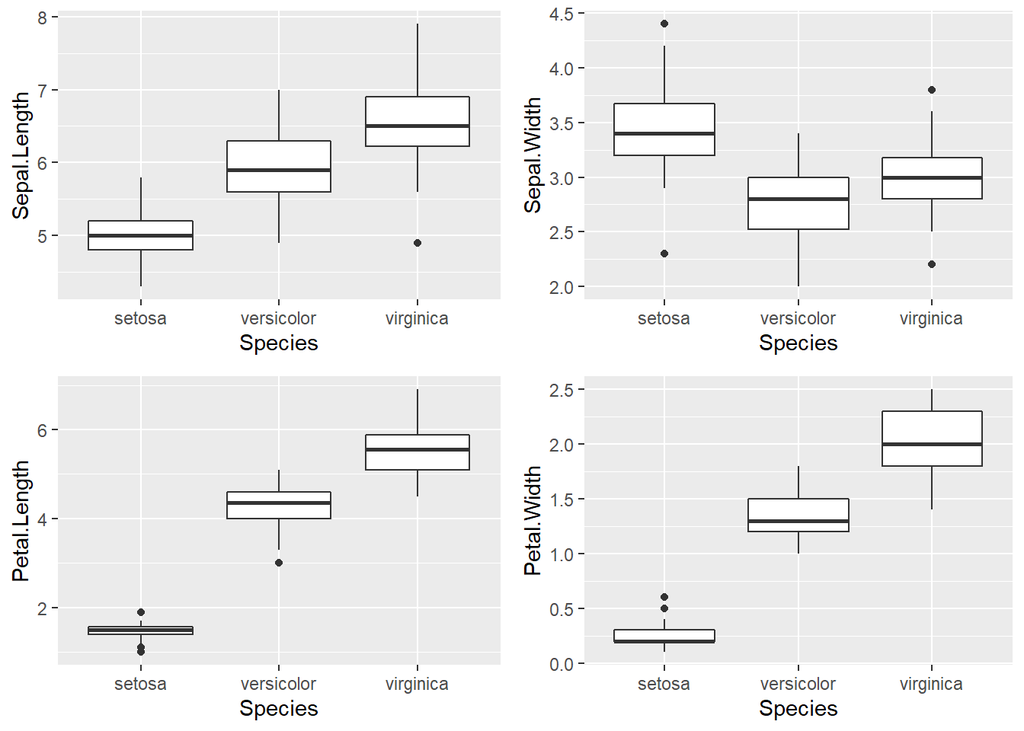

```r
#如何排版圖片
library(ggplot2)

library(gridExtra)
plot1<-ggplot(iris, aes(x=Species, y=Sepal.Length))+
  geom_boxplot()
plot2<-ggplot(iris, aes(x=Species, y=Sepal.Width))+
  geom_boxplot()
plot3<-ggplot(iris, aes(x=Species, y=Petal.Length))+
  geom_boxplot()
plot4<-ggplot(iris, aes(x=Species, y=Petal.Width))+
  geom_boxplot()
grid.arrange(plot1, plot2, plot3, plot4, nrow=2, ncol=2)
```